# Git and GitHub

Rockefeller University, Bioinformatics Resource Center

https://rockefelleruniversity.github.io/RU_reproducibleR/

These exercises follow the material in the GitHub section of [Reproducible R](https://rockefelleruniversity.github.io/RU_reproducibleR//).

1. Command line Git
- Create a new folder called GitHub_Training, and turn it into a git repository using the git command line.
- Create a README.md. Write in the name of a TV show.
- Copy the dayOfWeek Rscript from the *data* directory to the GitHub_Training directory.
- Add and commit each the README and the Rscript separately.
- Create a project on GitHub. Add this as a remote to your local Git for GitHub_Training.
- Push changes up to the remote.

```bash
mkdir GitHub_Training
cd GitHub_Training
git init
touch README.md
echo 'The Twilight Zone' >> README.md
cp ../data/dayOfWeek.r .
git add README.md
git commit -m"create README"
git commit -m"add days of week script"
git remote add origin https://github.com/BRC-RU/GitHub_Training.git
git push origin master
```

2. RStudio Git Integration
- Create a version controlled R project. Link this to your GitHub_Training remote. Save this in a different place to the Git repository you created in section 1 with command line Git.
- Update the README.md to include the name of a movie.
- Create a new Rmarkdown. Within this source the dayOfWeek Rscript. Add session information. and then compile the Rmarkdown to HTML.
- Update the .gitignore so Rmd files are ignored.
- Stage and commit changes through RStudio. *Remember to not commit every change together. Commit changes that make sense together.*
- Push changes up to GitHub.
3. Workflow and Collaboration Next we will practice the GitHub workflow. To do this we will use the repository [here](https://github.com/BRC-RU/GitHub_Training_GIFS). This is my collection of GIFS for how this training session makes me feel, and you can add to this.
- Contribute to the issues. Either create a new one, or add comments to existing issues.
- Take a fork of the repository. You can create a local copy through RStudio or command line git.
- Find GIF that you like. ([GIPHY](https://giphy.com/) has lots of options). Copy the URL.
- Open up the README.md document. Add a line to insert you GIF to the README.md. An example line is here: <img src=“https://my_gif_url_here.gif” width=“300”/>
- Create a pull request to merge your fork back into the main repository.
4. Build a Docker image from Github
- Take a fork of this repository: https://github.com/RockefellerUniversity/reproducibility_exercise
- Create a local copy by cloning the repository
- You’ll notice there is a Dockerfile in the directory that you have created. Currently, this Dockerfile only installs the pseudo-aligner software Salmon.
- Make the same plot that we made in the Docker exercises using the Docker image from Docker Hub.
  - This Dockerfile does not have ggplot2, add a line of code to make sure ggplot2 will be installed in an image built form this Dockerfile.
  - Build an image from this revised Dockerfile
  - Run a container from this image and open an RStudio session in your browser. HINT: make sure you mount the directory of the cloned repository (on your computer) onto the Docker container.
  - Activate the conda environment that contains salmon and confirm the version that you have installed
  - Use salmon to get counts for the fastq files present in the folder from the cloned repository.
    - code for indexing salmon: salmon index -t /path/to/fasta_file.fa -i /path/to/index_destination
    - code for pseudo-alignment: salmon quant -i /path/to/index_destination -l A -1 path/to/reads_1.fastq -2 path/to/reads_2.fastq –output path/to/output_dir
    - learn more with the [salmon manual](https://salmon.readthedocs.io/en/latest/salmon.html#)
  - Read in the quant.sf result file into your RStudio session and make a bar graph showing the number of reads for each of the genes in the fasta file.
    - save a png or pdf of the plot in the cloned repository directory
  - Add the revised Dockerfile and the plot to the git repositoy on your computer
  - Push these changes to your forked repository on Github.

```bash
# clone using git on terminal
git clone https://github.com/dougbarrows/reproducibility_exercise

# navigate to the directory we just made from cloning
cd reproducibility_exercise
```

```
## Edited Dockerfile
```

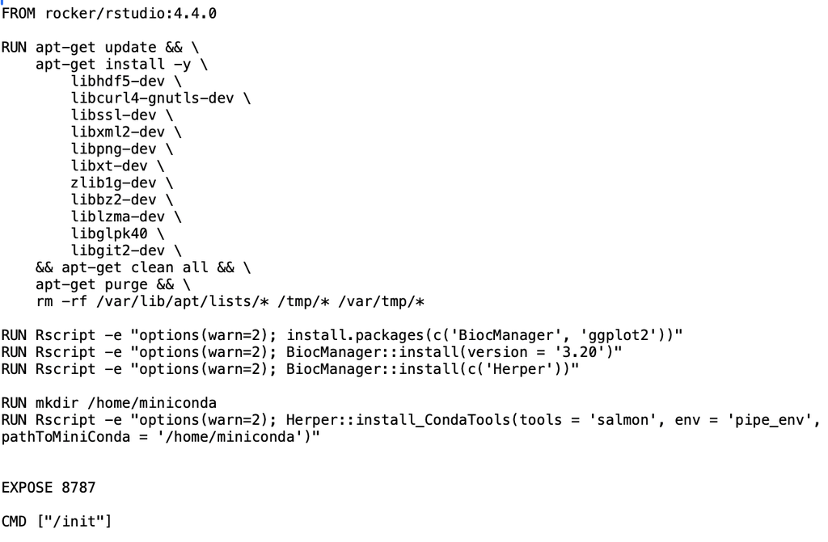

```bash
# build the image
docker image build -t salmon_with_ggplot2 .
docker container run --rm \
          -v .:/home/rstudio \
          -p 8787:8787 \
           -e PASSWORD=password123 \
           salmon_with_ggplot2
```

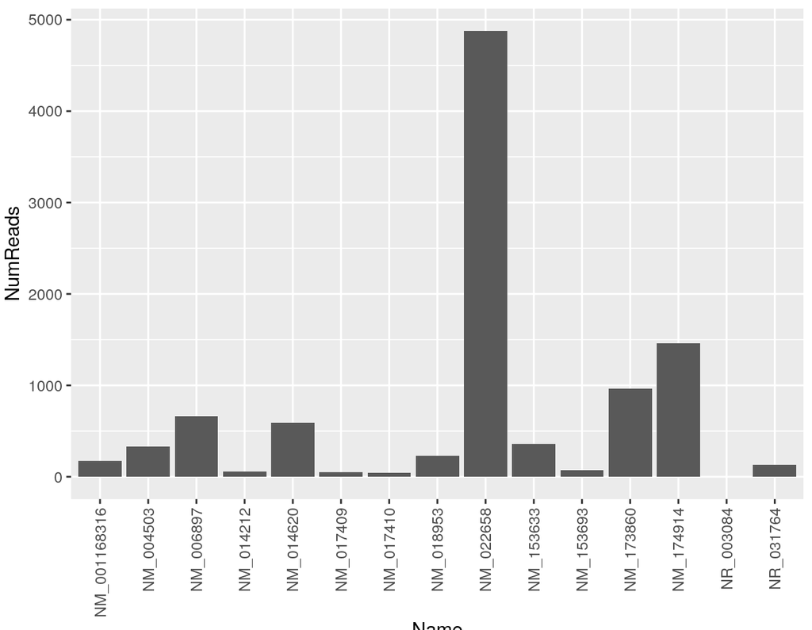

```r
# open up the RStudio session at http://localhost:8787/

# activate the conda environment
Herper::local_CondaEnv("pipe_env", "/home/miniconda")
system("salmon --version")

# index and count with salmon
system("salmon index -t transcripts.fasta -i transcripts_index")
system("salmon quant -i transcripts_index -l A -1 reads_1.fastq -2 reads_2.fastq --output sample_counts")

library(ggplot2)
counts <- read.table("sample_counts/quant.sf", header = T)
ggplot(counts, aes(x = Name, y = NumReads)) +
  geom_bar(stat = "identity") +
  theme(axis.text.x = element_text(angle = 90, vjust = 0.5, hjust=1))
ggsave("exercise_plot.pdf")
```

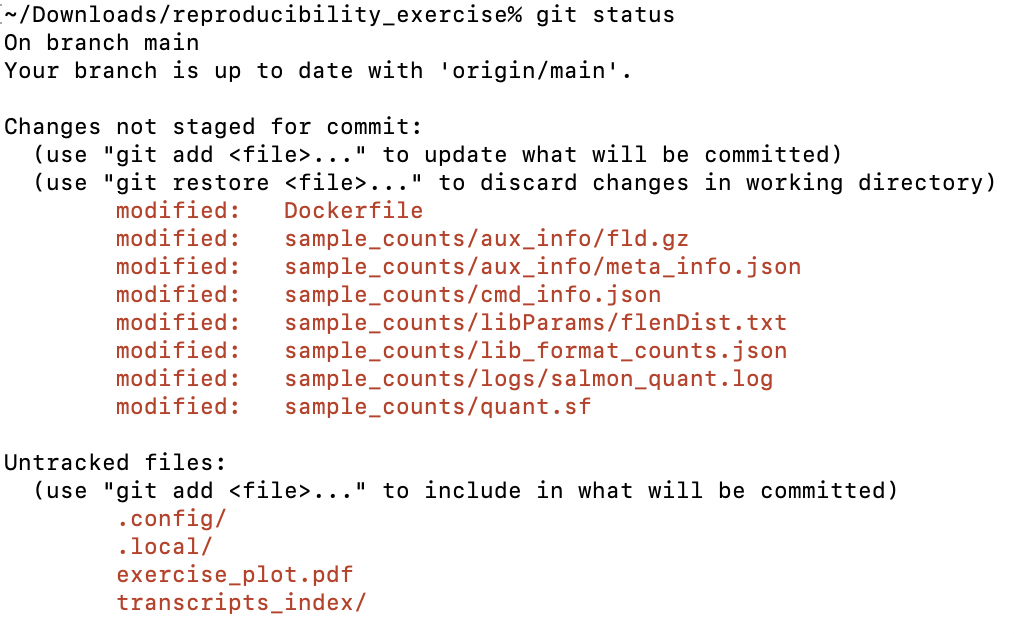

```bash
# look at files that have changed in git repo
git status
```

[figure not shown]

```bash
# look at files that have changed in git repo
git add Dockerfile exercise_plot.pdf
git commit -m "added ggplot and plot"
git push origin main
```